# Final Project: Submission

#### Tuning hyperparameters with GridSearchCV

Taking the full model and tuning the hyperparameters with grid search cross-validation results in a slight increase in performance, from `~0.953` to `~0.964`. For this model, best parameters turned out to be increasing `n=6` to `n=9`.

```
Best params: {'n_neighbors': 9, 'p': 1, 'weights': 'distance'}
Top 10 configurations:
```

|  | param_n_neighbors | param_p | param_weights | mean_test_score |
| --- | --- | --- | --- | --- |
| 81 | 9 | 1 | distance | 0.933427 |
| 91 | 10 | 1 | distance | 0.932452 |
| 63 | 7 | 2 | distance | 0.928088 |
| 65 | 7 | 3 | distance | 0.927598 |
| 95 | 10 | 3 | distance | 0.927598 |
| 87 | 9 | 4 | distance | 0.927595 |
| 97 | 10 | 4 | distance | 0.927110 |
| 85 | 9 | 3 | distance | 0.926625 |
| 75 | 8 | 3 | distance | 0.926625 |
| 73 | 8 | 2 | distance | 0.926144 |

```
---------- K-NN All tuned

Features: 44
Train data: 2058; Attrition: 332
Test data: 882; Attrition: 142

Model hyperparameters:
{
    "algorithm": "auto",
    "leaf_size": 30,
    "metric": "minkowski",
    "metric_params": null,
    "n_jobs": null,
    "n_neighbors": 9,
    "p": 1,
    "weights": "distance"
}

Model accuracy: 0.963718820861678

              precision    recall  f1-score   support

           0       0.96      0.99      0.98       740
           1       0.97      0.80      0.88       142

    accuracy                           0.96       882
   macro avg       0.96      0.90      0.93       882
weighted avg       0.96      0.96      0.96       882
```

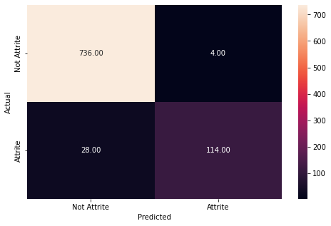

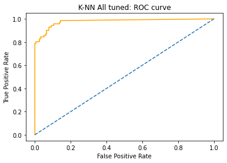

```python
def grid_search_knn_all():
    # Tuning KNN using all features
    knn_full = Model(
        title='K-NN All tuned',
        model=KNeighborsClassifier(),
        features=X_scaled,
        labels=Y
    )

    best_params = knn_full.get_grid_search_results({
        'n_neighbors': range(1, 11),
        'weights': ['uniform', 'distance'],
        'p': range(1, 6)
    })

    # Evaluate K-NN with tuned parameters
    knn_full.instance.set_params(**best_params)
    knn_full.evaluate()
    knn_full.display_roc_curve()

grid_search_knn_all()
```

Taking the all scalar model and tuning the hyperparameters with grid search cross-validation actually results in a slightly improved, with a `~0.946` accuracy in comparison to `~0.961`, roughly the same as the all feature model.

```
Best params: {'n_neighbors': 10, 'p': 1, 'weights': 'distance'}
Top 10 configurations:
```

|  | param_n_neighbors | param_p | param_weights | mean_test_score |
| --- | --- | --- | --- | --- |
| 91 | 10 | 1 | distance | 0.928073 |
| 81 | 9 | 1 | distance | 0.927588 |
| 45 | 5 | 3 | distance | 0.927107 |
| 61 | 7 | 1 | distance | 0.927107 |
| 71 | 8 | 1 | distance | 0.927101 |
| 85 | 9 | 3 | distance | 0.925651 |
| 73 | 8 | 2 | distance | 0.925166 |
| 95 | 10 | 3 | distance | 0.925166 |
| 75 | 8 | 3 | distance | 0.925165 |
| 43 | 5 | 2 | distance | 0.924676 |

```
---------- K-NN All scalar tuned

Features: 19
Train data: 2058; Attrition: 332
Test data: 882; Attrition: 142

Model hyperparameters:
{
    "algorithm": "auto",
    "leaf_size": 30,
    "metric": "minkowski",
    "metric_params": null,
    "n_jobs": null,
    "n_neighbors": 10,
    "p": 1,
    "weights": "distance"
}

Model accuracy: 0.9614512471655329

              precision    recall  f1-score   support

           0       0.96      0.99      0.98       740
           1       0.95      0.80      0.87       142

    accuracy                           0.96       882
   macro avg       0.96      0.90      0.92       882
weighted avg       0.96      0.96      0.96       882
```

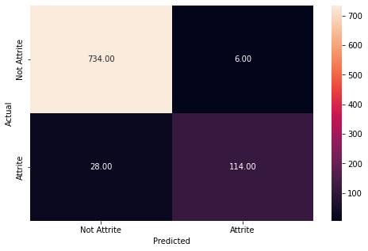

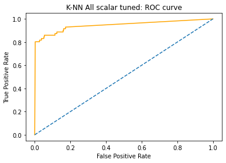

```python
def grid_search_knn_all_scalar():
    # Tuning KNN using all scalar features
    knn_full = Model(
        title='K-NN All scalar tuned',
        model=KNeighborsClassifier(),
        features=X_scaled.get(scalar_features),
        labels=Y
    )

    best_params = knn_full.get_grid_search_results({
        'n_neighbors': range(1, 11),
        'weights': ['uniform', 'distance'],
        'p': range(1, 6)
    })

    # Evaluate K-NN with tuned parameters
    knn_full.instance.set_params(**best_params)
    knn_full.evaluate()
    knn_full.display_roc_curve()

grid_search_knn_all_scalar()
```

By comparison, tuning the model on the arbitrary reduced feature set yielded a slight increase in accuracy, with `~0.934` in comparison to the original `~0.930`

```
Best params: {'n_neighbors': 10, 'p': 5, 'weights': 'distance'}
Top 10 configurations:
```

|  | param_n_neighbors | param_p | param_weights | mean_test_score |
| --- | --- | --- | --- | --- |
| 99 | 10 | 5 | distance | 0.906692 |
| 85 | 9 | 3 | distance | 0.906690 |
| 87 | 9 | 4 | distance | 0.906690 |
| 89 | 9 | 5 | distance | 0.906690 |
| 83 | 9 | 2 | distance | 0.906203 |
| 97 | 10 | 4 | distance | 0.905719 |
| 95 | 10 | 3 | distance | 0.905234 |
| 73 | 8 | 2 | distance | 0.904747 |
| 75 | 8 | 3 | distance | 0.904747 |
| 91 | 10 | 1 | distance | 0.904747 |

```
---------- K-NN Reduced tuned

Features: 3
Train data: 2058; Attrition: 332
Test data: 882; Attrition: 142

Model hyperparameters:
{
    "algorithm": "auto",
    "leaf_size": 30,
    "metric": "minkowski",
    "metric_params": null,
    "n_jobs": null,
    "n_neighbors": 10,
    "p": 5,
    "weights": "distance"
}

Model accuracy: 0.9342403628117913

              precision    recall  f1-score   support

           0       0.97      0.95      0.96       740
           1       0.78      0.83      0.80       142

    accuracy                           0.93       882
   macro avg       0.87      0.89      0.88       882
weighted avg       0.94      0.93      0.94       882
```

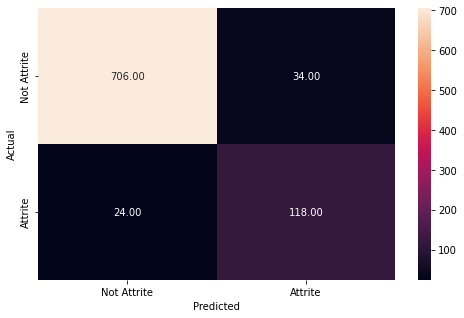

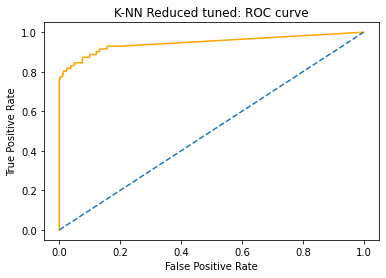

```python
def grid_search_knn_reduced():
    # Tuning KNN using reduced features
    knn_reduced = Model(
        title='K-NN Reduced tuned',
        model=KNeighborsClassifier(),
        features=X_scaled.get([
            'Age',
            'MonthlyIncome',
            'JobLevel'
        ]),
        labels=Y
    )

    best_params = knn_reduced.get_grid_search_results({
        'n_neighbors': range(1, 11),
        'weights': ['uniform', 'distance'],
        'p': range(1, 6)
    })

    # Evaluate K-NN with tuned parameters
    knn_reduced.instance.set_params(**best_params)
    knn_reduced.evaluate()
    knn_reduced.display_roc_curve()

grid_search_knn_reduced()
```

This is likewise seen with the PCA selected features, with a modest improvement from `~0.940` to `~0.946`.

```
Best params: {'n_neighbors': 10, 'p': 4, 'weights': 'distance'}
Top 10 configurations:
```

|  | param_n_neighbors | param_p | param_weights | mean_test_score |
| --- | --- | --- | --- | --- |
| 97 | 10 | 4 | distance | 0.922726 |
| 99 | 10 | 5 | distance | 0.922726 |
| 95 | 10 | 3 | distance | 0.921266 |
| 75 | 8 | 3 | distance | 0.920300 |
| 79 | 8 | 5 | distance | 0.920300 |
| 87 | 9 | 4 | distance | 0.920297 |
| 93 | 10 | 2 | distance | 0.920296 |
| 77 | 8 | 4 | distance | 0.919814 |
| 89 | 9 | 5 | distance | 0.919811 |
| 85 | 9 | 3 | distance | 0.918353 |

```
---------- K-NN Reduced tuned

Features: 4
Train data: 2058; Attrition: 332
Test data: 882; Attrition: 142

Model hyperparameters:
{
    "algorithm": "auto",
    "leaf_size": 30,
    "metric": "minkowski",
    "metric_params": null,
    "n_jobs": null,
    "n_neighbors": 10,
    "p": 4,
    "weights": "distance"
}

Model accuracy: 0.9455782312925171

              precision    recall  f1-score   support

           0       0.96      0.97      0.97       740
           1       0.85      0.80      0.83       142

    accuracy                           0.95       882
   macro avg       0.91      0.89      0.90       882
weighted avg       0.94      0.95      0.94       882
```

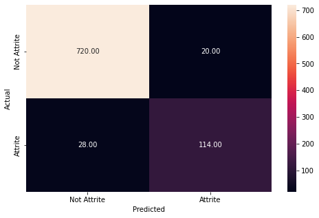

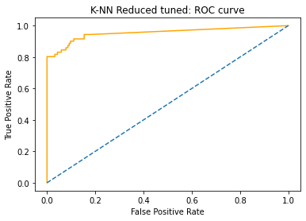

```python
def grid_search_knn_tuned():
    # Tuning KNN using reduced features
    knn_reduced = Model(
        title='K-NN Reduced tuned',
        model=KNeighborsClassifier(),
        features=X_scaled.get([
            'OverTime',
            'Age',
            'MonthlyIncome',
            'TotalWorkingYears'
        ]),
        labels=Y
    )

    best_params = knn_reduced.get_grid_search_results({
        'n_neighbors': range(1, 11),
        'weights': ['uniform', 'distance'],
        'p': range(1, 6)
    })

    # Evaluate K-NN with tuned parameters
    knn_reduced.instance.set_params(**best_params)
    knn_reduced.evaluate()
    knn_reduced.display_roc_curve()

grid_search_knn_tuned()
```

## Decision Trees

With a decreased performance in comparison to the K-NN of `~0.941`, it uses a relatively complex tree to do so, with a maximum depth of 17 levels and 192 leaf nodes.

```
---------- Decision Tree Reduced

Features: 44
Train data: 2058; Attrition: 332
Test data: 882; Attrition: 142

Model hyperparameters:
{
    "ccp_alpha": 0.0,
    "class_weight": {
        "0": 0.17,
        "1": 0.83
    },
    "criterion": "gini",
    "max_depth": null,
    "max_features": null,
    "max_leaf_nodes": null,
    "min_impurity_decrease": 0.0,
    "min_samples_leaf": 1,
    "min_samples_split": 2,
    "min_weight_fraction_leaf": 0.0,
    "random_state": 0,
    "splitter": "best"
}

Model accuracy: 0.9410430839002267

              precision    recall  f1-score   support

           0       0.97      0.96      0.96       740
           1       0.79      0.86      0.82       142

    accuracy                           0.94       882
   macro avg       0.88      0.91      0.89       882
weighted avg       0.94      0.94      0.94       882
```

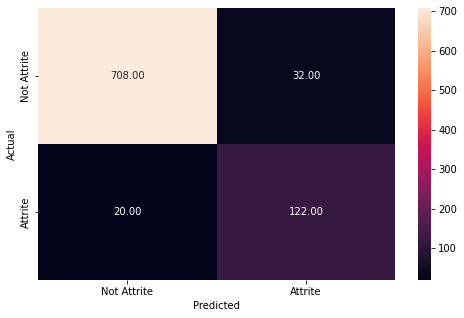

```
Tree depth: 17
Tree leaves: 192
```

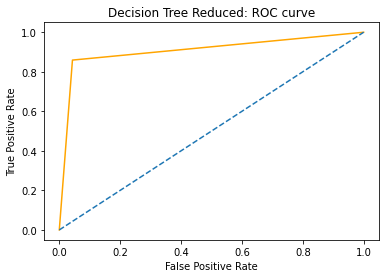

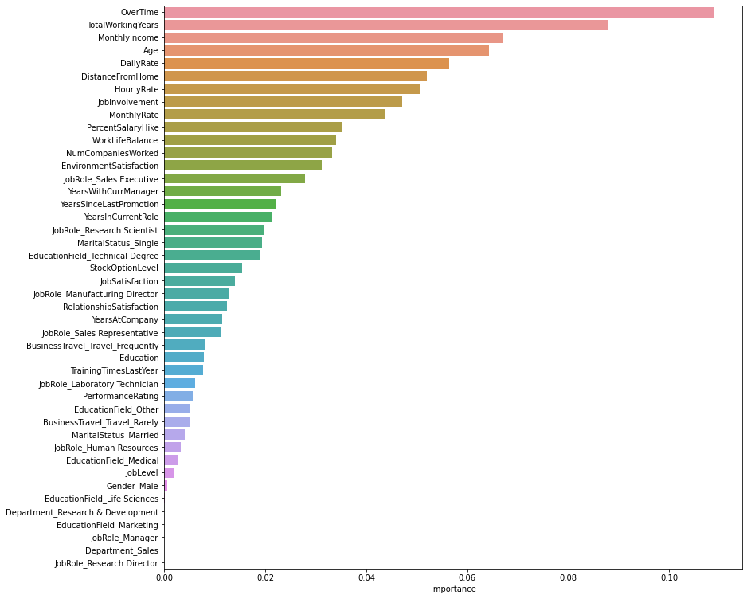

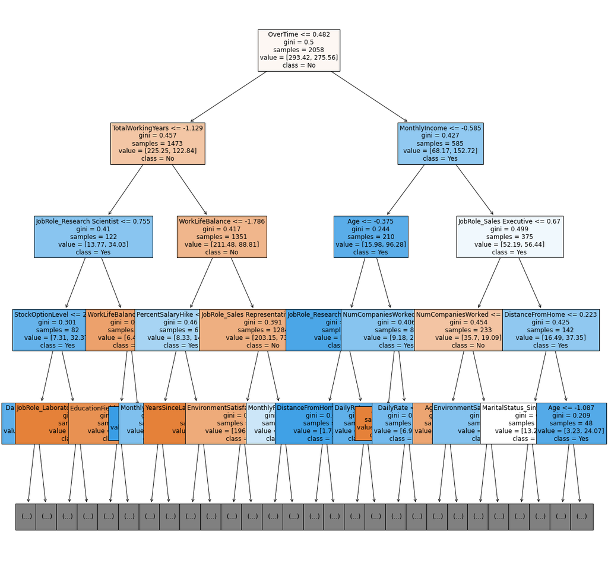

```python
# Building decision tree with class weight to deal with unbalanced dataset.
balanced_class_weight = { 0:0.17, 1:0.83 }

# Decision tree using reduced features without normalization
tree_all = Model(
    title='Decision Tree Reduced',
    model=DecisionTreeClassifier(class_weight=balanced_class_weight, random_state=0),
    features=X_scaled,
    labels=Y
)

tree_all.evaluate()
print(f'\nTree depth: {tree_all.instance.get_depth()}\nTree leaves: {tree_all.instance.get_n_leaves()}')
tree_all.display_roc_curve()
tree_all.display_feature_importance()

fig, ax = plt.subplots()
fig.set_size_inches(20, 20)
_ = plot_tree(
        tree_all.instance,
        ax=ax,
        feature_names=X.columns,
        class_names=['No', 'Yes'],
        filled=True,
        fontsize=12,
        max_depth=4
    )
```

Using the top four important features of the tree results in a much more complex tree, with a depth of 23 and 279 leaf nodes, while at the same time having a slightly lower accuracy of `~0.937`.

```
---------- Decision Tree Reduced

Features: 4
Train data: 2058; Attrition: 332
Test data: 882; Attrition: 142

Model hyperparameters:
{
    "ccp_alpha": 0.0,
    "class_weight": null,
    "criterion": "gini",
    "max_depth": null,
    "max_features": null,
    "max_leaf_nodes": null,
    "min_impurity_decrease": 0.0,
    "min_samples_leaf": 1,
    "min_samples_split": 2,
    "min_weight_fraction_leaf": 0.0,
    "random_state": 0,
    "splitter": "best"
}

Model accuracy: 0.9365079365079365

              precision    recall  f1-score   support

           0       0.97      0.96      0.96       740
           1       0.79      0.83      0.81       142

    accuracy                           0.94       882
   macro avg       0.88      0.89      0.89       882
weighted avg       0.94      0.94      0.94       882
```

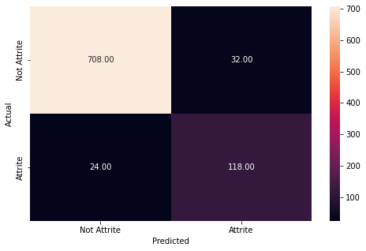

```
Tree depth: 23
Tree leaves: 279
```

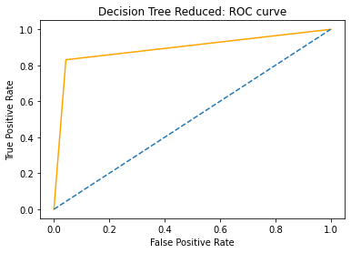

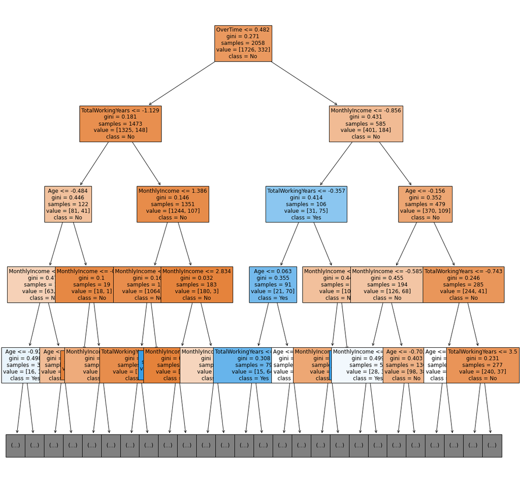

```python
# Decision Tree with limited leaf nodes using reduced features without normalization
tree_limited = Model(
    title='Decision Tree Reduced',
    model=DecisionTreeClassifier(random_state=0),
    features=X_scaled.get([
        'OverTime',
        'TotalWorkingYears',
        'MonthlyIncome',
        'Age'
    ]),
    labels=Y
)

tree_limited.evaluate()
print(f'\nTree depth: {tree_limited.instance.get_depth()}\nTree leaves: {tree_limited.instance.get_n_leaves()}')
tree_limited.display_roc_curve()


fig, ax = plt.subplots()
fig.set_size_inches(20, 20)
_ = plot_tree(
        tree_limited.instance,
        ax=ax,
        feature_names=[
            'OverTime',
            'TotalWorkingYears',
            'MonthlyIncome',
            'Age'
        ],
        class_names=['No', 'Yes'],
        filled=True,
        fontsize=12,
        max_depth=4
    )
```

#### Tuning hyperparameters with GridSearchCV

Another way to reduce complexity is to choose a cost complexity alpha value to incentize trees towards a more simpler represention. After selecting a number of promising alphas, a general cross-validation grid search was done to find the to tune the other decision tree hyperparameters. As it turns out, given the reduced feature set, the default tuning `0` pruning alpha is the most optimal, while using an entropy based criterion and a random splitter results in a slight bump in accuracy, from `~0.94` to `~0.95`, comparable to the K-NN model.

```
Top 10 cost complexity alphas
```

|  | accuracy | ccp_alpha |
| --- | --- | --- |
| 0 | 0.934240 | 0.000000 |
| 1 | 0.933107 | 0.000322 |
| 2 | 0.931973 | 0.000459 |
| 4 | 0.931973 | 0.000473 |
| 3 | 0.930839 | 0.000468 |
| 5 | 0.930839 | 0.000474 |
| 6 | 0.929705 | 0.000475 |
| 7 | 0.928571 | 0.000477 |
| 8 | 0.927438 | 0.000478 |
| 9 | 0.926304 | 0.000479 |

```
Best params: {'ccp_alpha': 0.0, 'criterion': 'entropy', 'splitter': 'random'}
Top 10 configurations:
```

|  | param_ccp_alpha | param_criterion | param_splitter | mean_test_score |
| --- | --- | --- | --- | --- |
| 3 | 0.0 | entropy | random | 0.906219 |
| 7 | 0.000322 | entropy | random | 0.906219 |
| 11 | 0.000459 | entropy | random | 0.906219 |
| 15 | 0.000473 | entropy | random | 0.906219 |
| 19 | 0.000468 | entropy | random | 0.906219 |
| 23 | 0.000474 | entropy | random | 0.906219 |
| 27 | 0.000475 | entropy | random | 0.906219 |
| 31 | 0.000477 | entropy | random | 0.906219 |
| 35 | 0.000478 | entropy | random | 0.906219 |
| 39 | 0.000479 | entropy | random | 0.906219 |

```
---------- Decision Tree Reduced Tuned

Features: 44
Train data: 2058; Attrition: 332
Test data: 882; Attrition: 142

Model hyperparameters:
{
    "ccp_alpha": 0.0,
    "class_weight": null,
    "criterion": "entropy",
    "max_depth": null,
    "max_features": null,
    "max_leaf_nodes": null,
    "min_impurity_decrease": 0.0,
    "min_samples_leaf": 1,
    "min_samples_split": 2,
    "min_weight_fraction_leaf": 0.0,
    "random_state": 0,
    "splitter": "random"
}

Model accuracy: 0.9501133786848073

              precision    recall  f1-score   support

           0       0.98      0.96      0.97       740
           1       0.83      0.87      0.85       142

    accuracy                           0.95       882
   macro avg       0.90      0.92      0.91       882
weighted avg       0.95      0.95      0.95       882
```

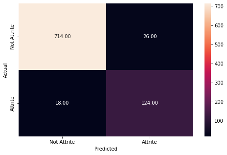

```
Tree depth: 18
Tree leaves: 189
```

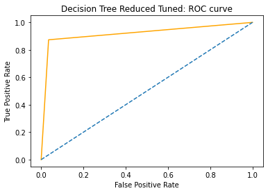

```python
def tree_tuned_hyperparameters():
    # Tuning decision tree with reduced features
    tree_reduced = Model(
        title='Decision Tree Reduced Tuned',
        model=DecisionTreeClassifier(random_state=0),
        features=X_scaled,
        labels=Y
    )

    # Find the best cost complexity pruning alpha values
    path = tree_reduced.instance.cost_complexity_pruning_path(
        tree_reduced.train_data,
        tree_reduced.train_labels
    )

    table = {
        'accuracy': [],
        'ccp_alpha': path.ccp_alphas
    }

    for ccp_alpha in path.ccp_alphas:
        tree = Model(
            title='Decision Tree Reduced Tuned',
            model=DecisionTreeClassifier(ccp_alpha=ccp_alpha, random_state=0),
            features=X_scaled,
            labels=Y
        )
        accuracy = tree.instance.fit(tree.train_data, tree.train_labels)\
                                .score(tree.test_data, tree.test_labels)
        table['accuracy'].append(accuracy)

    top = 10
    table_best = pd.DataFrame(table).nlargest(top, columns=['accuracy'])
    print(f'Top {top} cost complexity alphas')
    display(table_best)

    # Do a grid search on the top values
    best_params = tree_reduced.get_grid_search_results({
        'criterion': ['gini', 'entropy'],
        'splitter': ['best', 'random'],
        'ccp_alpha': table_best['ccp_alpha'].values
    })

    # Evaluate the best parameters
    tree_reduced.instance.set_params(**best_params)
    tree_reduced.evaluate()
    print(f'\nTree depth: {tree_reduced.instance.get_depth()}\nTree leaves: {tree_reduced.instance.get_n_leaves()}')
    tree_reduced.display_roc_curve()

tree_tuned_hyperparameters()
```

### **Building the Random Forest Classifier**

**Random Forest is a bagging algorithm where the base models are Decision Trees.** Samples are taken from the training data and on each sample a decision tree makes a prediction.

**The results from all the decision trees are combined together and the final prediction is made using voting or averaging.**

```python
#Fitting the decision tree classifier on the training data
rf_estimator = RandomForestClassifier(class_weight={0:0.17,1:0.83}, random_state=1)

rf_estimator.fit(x_train,y_train)
```

```
RandomForestClassifier(class_weight={0: 0.17, 1: 0.83}, random_state=1)
```

```
              precision    recall  f1-score   support

           0       1.00      1.00      1.00      1726
           1       1.00      1.00      1.00       332

    accuracy                           1.00      2058
   macro avg       1.00      1.00      1.00      2058
weighted avg       1.00      1.00      1.00      2058
```

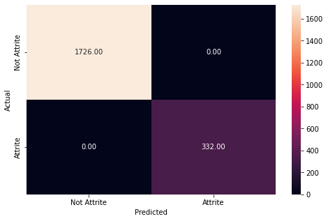

```python
#Checking performance on the training data
y_pred_train_rf = rf_estimator.predict(x_train)
metrics_score(y_train, y_pred_train_rf)
```

**Observations:**

- The Random Forest is giving a **100% result on the training dataset.**

```
              precision    recall  f1-score   support

           0       0.96      1.00      0.98       740
           1       0.98      0.79      0.88       142

    accuracy                           0.96       882
   macro avg       0.97      0.89      0.93       882
weighted avg       0.96      0.96      0.96       882
```

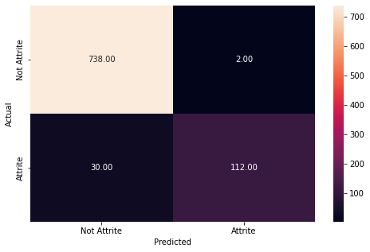

```python
#Checking performance on the testing data
y_pred_test_rf = rf_estimator.predict(x_test)
metrics_score(y_test, y_pred_test_rf)
```

**Observations:**

- The Random Forest classifier **seems to be overfitting on the data**, since the training recall is 1 and the testing recall is only ~0.80.
- Precision on the test data using the Random Forest is doing very well.

**Features importance of the random forest model:**

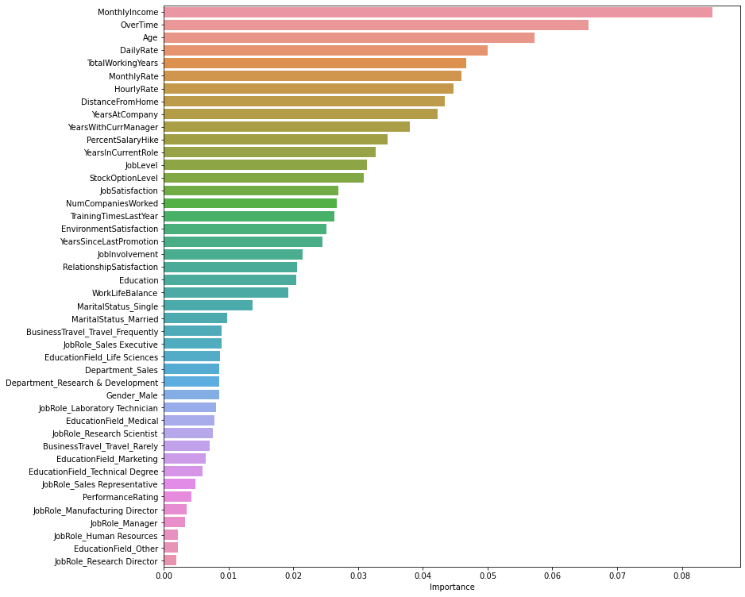

```python
importances = rf_estimator.feature_importances_
columns=X.columns
importance_df=pd.DataFrame(importances,index=columns,columns=['Importance']).sort_values(by='Importance',ascending=False)
plt.figure(figsize=(13,13))
sns.barplot(importance_df.Importance,importance_df.index)
```

**Observations:**

- The Random Forest further verifies the results from the decision tree - the most important features are `MonthlyIncome`, `Age`, `OverTime`, `TotalWorkingYears` and `DailyRate`.
- We can say that the people appear to be leaving the organization because of the overtime they are doing and because they are not paid accordingly. These might be mostly junior-level and mid-level employees with less experience.
- Distance from home is also a key feature, probably as employees living far from the office have to travel a lot, making their schedules hectic.
- Not having stock options is also a driver for attrition - this feature seems to have good importance in both the decision tree and random forest models. This could be related to the junior level employees and their lack of stock options - with the additional burden of a lower salary and working overtime, those without stock options could also be attriting more.
- Other features like, number of companies worked and percent salary hike also seem to be intuitive in explaining attrition likelihood, as people who have worked in a large number of companies are probably not going to stay loyal to the current organization and may have a high risk of attrition, while if an employee is not getting enough of a salary hike, that might demotivate them and lead to a higher likelihood of attriting as well.
- Other features such as job satisfaction, environment satisfaction and their job level also play a crucial role in knowing whether an employee will attrite or not.

### **Tuning the Random Forest**

**n_estimators**: The number of trees in the forest.

**min_samples_split**: The minimum number of samples required to split an internal node:

**min_samples_leaf**: The minimum number of samples required to be at a leaf node.

**max_features{“auto”, “sqrt”, “log2”, 'None'}**: The number of features to consider when looking for the best split.

- If “auto”, then max_features=sqrt(n_features).
- If “sqrt”, then max_features=sqrt(n_features) (same as “auto”).
- If “log2”, then max_features=log2(n_features).
- If None, then max_features=n_features.

```python
# Choose the type of classifier
## check w brian code to use grid search
rf_estimator_tuned = RandomForestClassifier(class_weight={0:0.17,1:0.83}, random_state=1)

# Grid of parameters to choose from
## add from article
params_rf = {
        "n_estimators": [100,250,500],
        "min_samples_leaf": np.arange(1, 4,1),
        "max_features": [0.7,0.9,'auto'],
}


# Type of scoring used to compare parameter combinations - recall score for class 1
scorer = metrics.make_scorer(recall_score, pos_label=1)

# Run the grid search
grid_obj = GridSearchCV(rf_estimator_tuned, params_rf, scoring=scorer, cv=5)
grid_obj = grid_obj.fit(x_train, y_train)

# Set the classifier to the best combination of parameters
rf_estimator_tuned = grid_obj.best_estimator_
```

```python
rf_estimator_tuned.fit(x_train, y_train)
```

```
RandomForestClassifier(class_weight={0: 0.17, 1: 0.83}, max_features=0.7,
                       min_samples_leaf=3, n_estimators=500, random_state=1)
```

```
              precision    recall  f1-score   support

           0       1.00      1.00      1.00      1726
           1       0.99      1.00      1.00       332

    accuracy                           1.00      2058
   macro avg       1.00      1.00      1.00      2058
weighted avg       1.00      1.00      1.00      2058
```

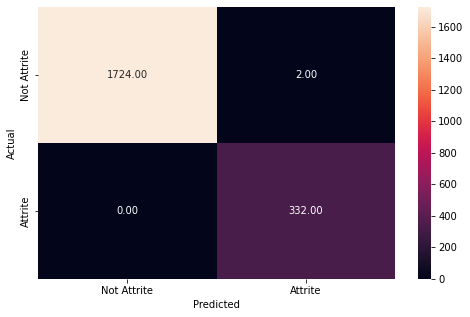

```python
#Checking performance on the training data
y_pred_train_rf_tuned = rf_estimator_tuned.predict(x_train)
metrics_score(y_train, y_pred_train_rf_tuned)
```

```
              precision    recall  f1-score   support

           0       0.97      0.98      0.97       740
           1       0.88      0.83      0.86       142

    accuracy                           0.95       882
   macro avg       0.92      0.90      0.91       882
weighted avg       0.95      0.95      0.95       882
```

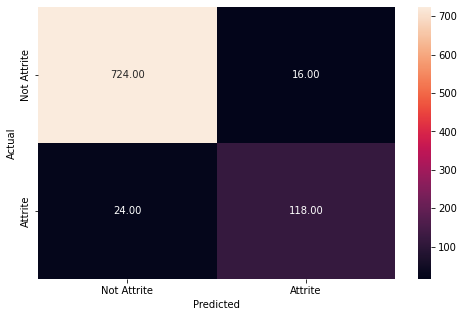

```python
#Checking performance on the test data
y_pred_test_rf_tuned = rf_estimator_tuned.predict(x_test)
metrics_score(y_test, y_pred_test_rf_tuned)
```

**Observations:**

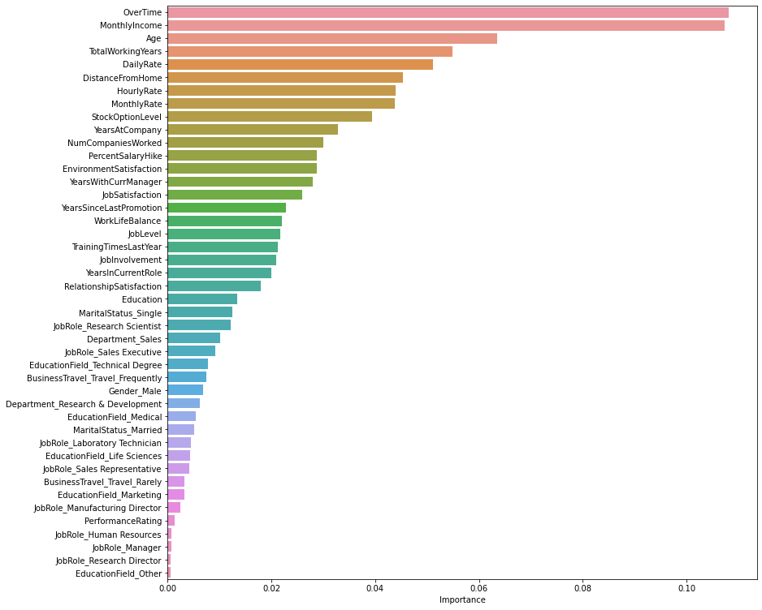

```python
#plotting feature importance
importances = rf_estimator_tuned.feature_importances_
columns=X.columns
importance_df=pd.DataFrame(importances,index=columns,columns=['Importance']).sort_values(by='Importance',ascending=False)
plt.figure(figsize=(13,13))
sns.barplot(importance_df.Importance,importance_df.index)
```

**Observations:**

- **The feature importance plot for the base model and tuned model are quite similar** - the model seems to suggest that OverTime, MonthlyIncome, Age,TotalWorkingYears and DailyRate are the most important features.
- Other important features are DistanceFromHome, StockOptionLevel, YearsAt Company and NumCompaniesWorked.

### **Recommendations**

- **Working overtime is the most important driver of attrition.** The organization should manage their work more efficiently so that employees don't have to work overtime and can manage to have a work-life balance, or failing this, the company could provide some additional incentives to employees who are working overtime in order to retain them.
- **A higher monthly income might lower the odds of an employee attriting.** The company should make sure that all its employees are compensated at least based on industry standards.
- As observed earlier, the organization has a lower percentage salary hike and promotions are given less frequently. The company might be able to focus on **giving promotions more frequently** or they could **increase the annual appraisal hike** to incentivize employees to stay.
- The organization could come up with a **revised CTC plan with stock options for the employees** in order to keep them motivated and invested in the company's performance.
- The organization should also modify its hiring policy as people who have worked in many companies and have switched a lot should not be hired very often.
- Distance from home is also an important factor for attrition - employees traveling a larger distance to reach the workplace are the ones attriting. For such employees, the company can provide cab facilities so that the commute of employees gets easier.
- The company should also keep track of the hourly rate or the daily rate, so that when the employees need to stay overtime for extra work they are well compensated for that.
- The organization should focus on improving the culture and environment at the workplace by coming up with new ideas to make the environment more open and friendly.
- Keeping track of the problems which employees with lesser experience face and how the management can help them, will create a healthy environment for the young employees.
- The organization should also focus on the employees who are working in sales and marketing, as attrition rate is quite high for these departments. Perhaps the company could look into their incentive schemes and try to come up with new incentive methods to motivate them to stay.